# SES_Anat_Analyses

Lindsay Olson

2/10/2021

# Compare Q>=3 and Q>=4 Datasets

## Participant Table, Q>=4

```
##
##
## |          &nbsp;           | level  |          ASD          |           TD           |   p    | test |
## |:-------------------------:|:------:|:---------------------:|:----------------------:|:------:|:----:|
## |           **n**           |        |          28           |           27           |        |      |
## |        **SEX (%)**        | Female |       6 (21.4)        |       14 (51.9)        | 0.039  |      |
## |                           |  Male  |       22 (78.6)       |       13 (48.1)        |        |      |
## |  **V1.Age (mean (SD))**   |        |     39.39 (13.77)     |     39.56 (13.98)      | 0.965  |      |
## |  **MEL_cat (mean (SD))**  |        |      3.52 (1.60)      |      4.33 (1.05)       | 0.049  |      |
## |    **INR (mean (SD))**    |        |      3.35 (2.79)      |      4.37 (2.10)       | 0.180  |      |
## | **zipIncome (mean (SD))** |        |  53477.39 (18001.70)  |  57480.76 (15744.99)   | 0.439  |      |
## |   **SES1 (mean (SD))**    |        |     -0.40 (2.06)      |      0.62 (1.76)       | 0.054  |      |
## |   **SES2 (mean (SD))**    |        |     -0.27 (0.34)      |      -0.17 (0.27)      | 0.244  |      |
## | **ExpLang_T (mean (SD))** |        |     31.67 (11.07)     |     49.78 (11.10)      | <0.001 |      |
## | **RecLang_T (mean (SD))** |        |     32.32 (11.85)     |     53.85 (10.96)      | <0.001 |      |
## |  **ELC_SS (mean (SD))**   |        |     71.96 (20.00)     |     105.67 (15.78)     | <0.001 |      |
## |    **TBV (mean (SD))**    |        | 1077031.79 (96937.48) | 1050164.41 (111924.89) | 0.345  |      |
##
## Table: Participant Summary Table for Q>=4
```

## Participant Table, Q>=3

```
##
##
## |          &nbsp;           | level  |          ASD           |           TD           |   p    | test |
## |:-------------------------:|:------:|:----------------------:|:----------------------:|:------:|:----:|
## |           **n**           |        |           36           |           31           |        |      |
## |        **SEX (%)**        | Female |       10 (27.8)        |       14 (45.2)        | 0.221  |      |
## |                           |  Male  |       26 (72.2)        |       17 (54.8)        |        |      |
## |  **V1.Age (mean (SD))**   |        |     39.03 (12.95)      |     37.61 (14.20)      | 0.671  |      |
## |  **MEL_cat (mean (SD))**  |        |      3.54 (1.50)       |      4.36 (0.99)       | 0.019  |      |
## |    **INR (mean (SD))**    |        |      3.46 (2.75)       |      4.13 (2.14)       | 0.319  |      |
## | **zipIncome (mean (SD))** |        |  54158.10 (18734.17)   |  56118.68 (15004.41)   | 0.675  |      |
## |   **SES1 (mean (SD))**    |        |      -0.35 (1.97)      |      0.54 (1.66)       | 0.053  |      |
## |   **SES2 (mean (SD))**    |        |      -0.13 (0.90)      |      -0.05 (0.91)      | 0.733  |      |
## | **ExpLang_T (mean (SD))** |        |     32.62 (11.76)      |     48.77 (11.52)      | <0.001 |      |
## | **RecLang_T (mean (SD))** |        |     32.49 (12.52)      |     53.32 (11.13)      | <0.001 |      |
## |  **ELC_SS (mean (SD))**   |        |     72.23 (19.97)      |     104.94 (16.57)     | <0.001 |      |
## |    **TBV (mean (SD))**    |        | 1076827.78 (100384.08) | 1045805.34 (115665.34) | 0.244  |      |
##
## Table: Participant Summary Table for Q>=3
```

## Bivariate Correlation Plots, ASD&TD Together, Q>=4

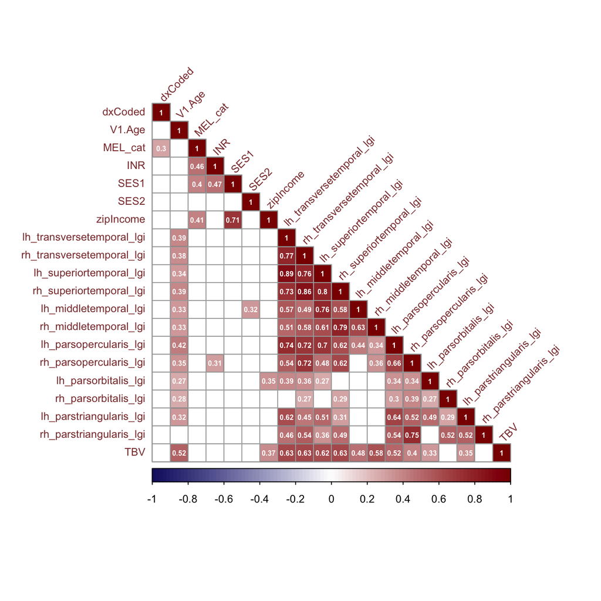

Bivariate Plot

## Bivariate Correlation ASD and TD, Q>=3

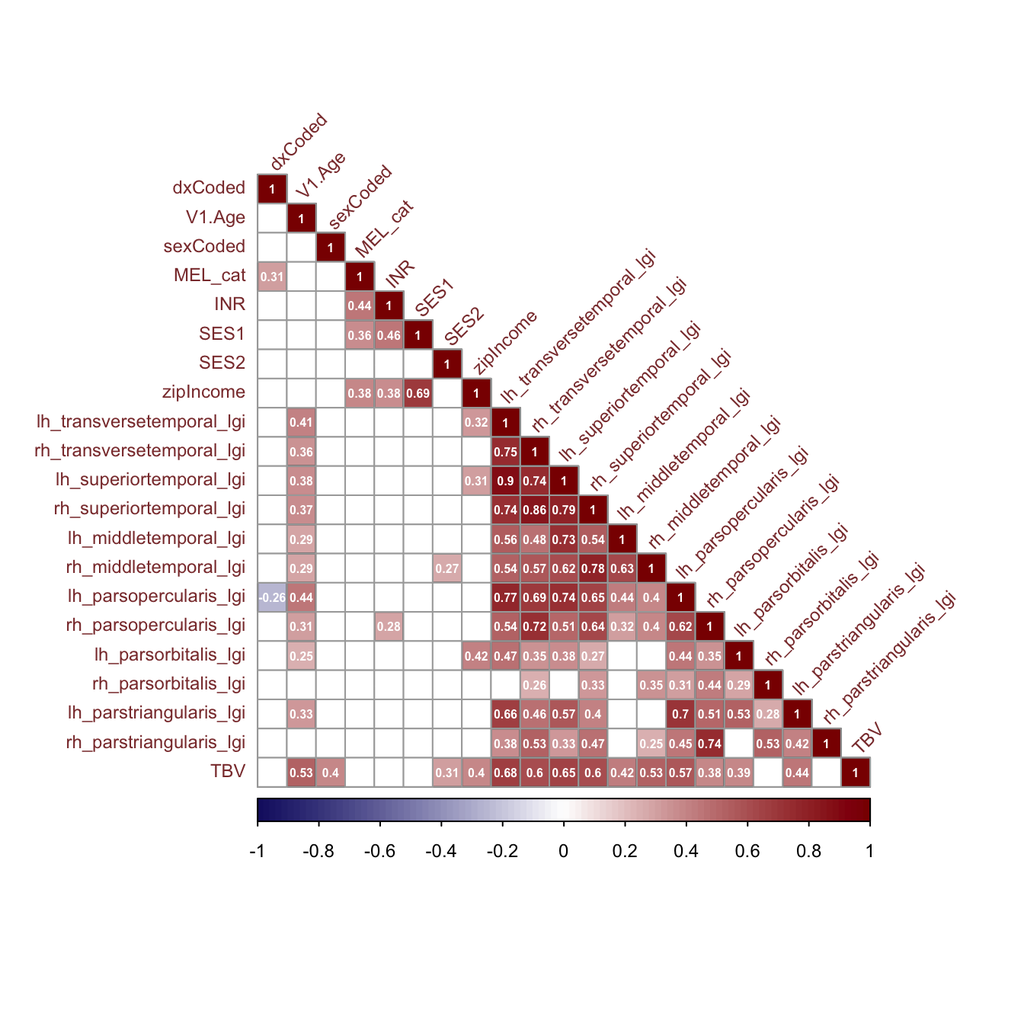

Bivariate Plot

## Bivariate correlations, ASD Only, Q>=4

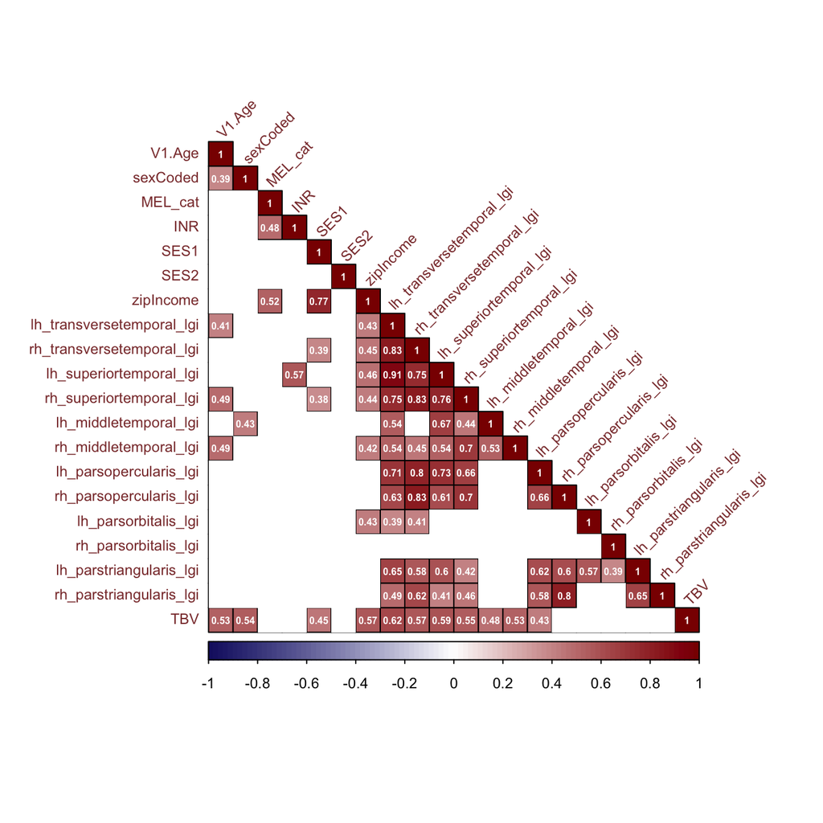

Bivariate Plot ASD Only

## Bivariate correlations, ASD Only, Q>=3

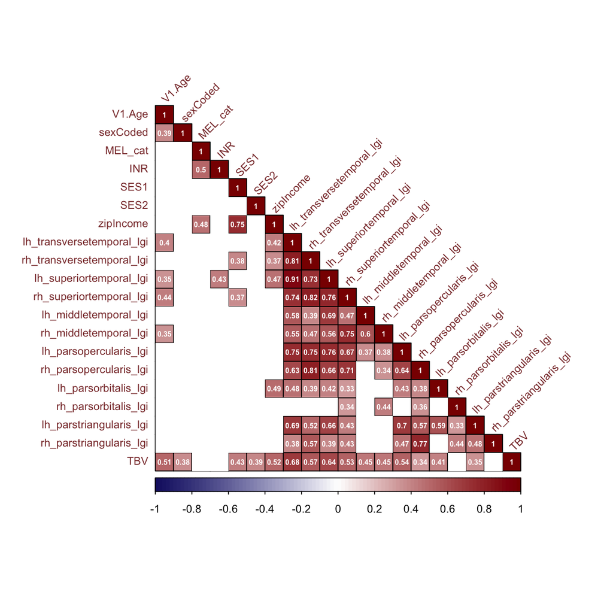

Bivariate Plot ASD Only

## Bivariate correlations, TD Only Q>=4

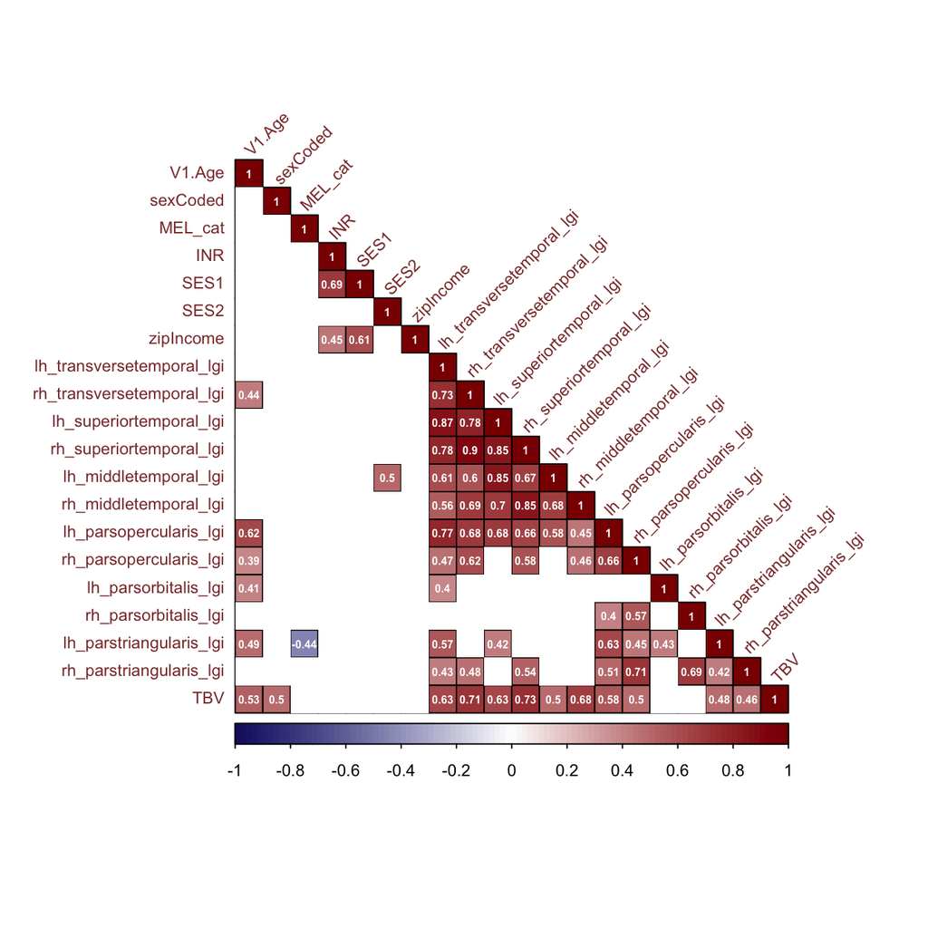

Bivariate Plot, TD Only

## Bivariate correlations, TD Only Q>=3

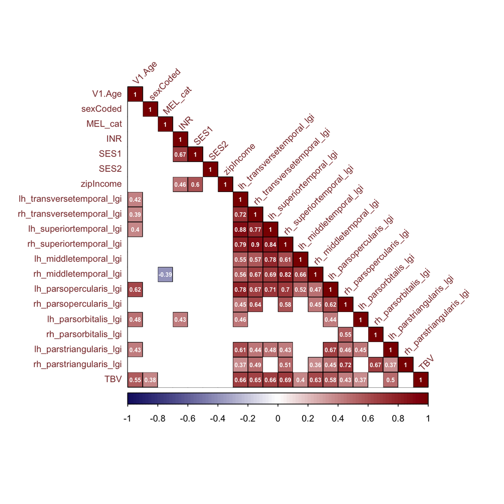

Bivariate Plot, TD Only

# LGI Results, compare results for data quality Q>=4 vs. data quality Q>=3, Regression Models: INR

## INR Results Q>=4

|  | rh_parsopercularis_lgi |  |  |
| --- | --- | --- | --- |
| Coeffcient | Estimates | CI (95%) | p-Value |
| Intercept | 3.48 | 2.46 – 4.50 | **<0.001** |
| Income:Needs | 0.04 | 0.01 – 0.08 | **0.026** |
| TBV | 0.00 | -0.00 – 0.00 | 0.125 |
| Age | 0.01 | 0.00 – 0.02 | **0.027** |
| Observations | 42 |  |  |
| R<sup>2</sup> / R<sup>2</sup> adjusted | 0.342 / 0.290 |  |  |

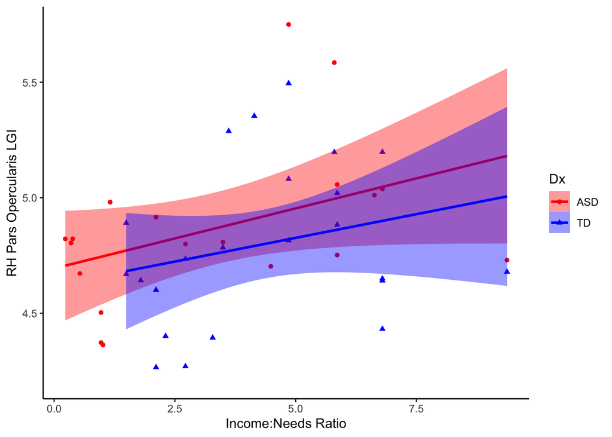

## INR Results Q>3

|  | rh_parsopercularis_lgi |  |  |
| --- | --- | --- | --- |
| Coeffcient | Estimates | CI (95%) | p-Value |
| Intercept | 3.74 | 2.91 – 4.58 | **<0.001** |
| Income:Needs | 0.03 | 0.00 – 0.07 | **0.045** |
| TBV | 0.00 | -0.00 – 0.00 | 0.144 |
| Age | 0.01 | 0.00 – 0.01 | **0.031** |
| Observations | 52 |  |  |
| R<sup>2</sup> / R<sup>2</sup> adjusted | 0.289 / 0.244 |  |  |

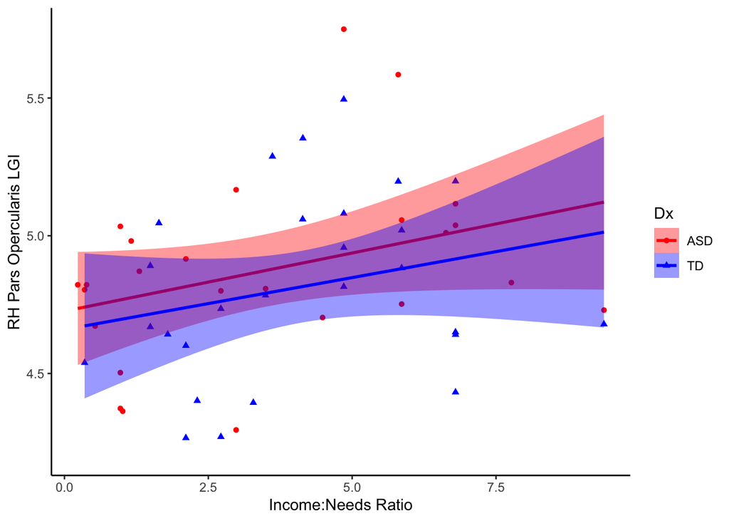

# LGI Results, compare restuls for data quality Q>=4 vs. data quality Q>=3, Regression Models SES1

## Neighborhood Advantage Results Q>=4

Neighborhood Advantage not a significant predictor of LGI when controlling for TBV and dx for Q>=4.

## Neighborhood Advantage Results Q>3

Neighborhood Advantage not a significant predictor of LGI when controlling for TBV and dx for data Q>=3.

# LGI Results, compare restuls for data quality Q>=4 vs. data quality Q>=3, Regression Models SES2

## Neighborhood Disadvantage Results Q>=4

|  | lh_fusiform_lgi |  |  |
| --- | --- | --- | --- |
| Coeffcient | Estimates | CI (95%) | p-Value |
| Intercept | 2.45 | 2.17 – 2.72 | **<0.001** |
| SES2 | 0.01 | -0.07 – 0.10 | 0.763 |
| TBV | 0.00 | 0.00 – 0.00 | **0.003** |
| Age | -0.00 | -0.00 – 0.00 | 0.050 |
| Observations | 55 |  |  |
| R<sup>2</sup> / R<sup>2</sup> adjusted | 0.170 / 0.122 |  |  |

|  | rh_fusiform_lgi |  |  |
| --- | --- | --- | --- |
| Coeffcient | Estimates | CI (95%) | p-Value |
| Intercept | 2.29 | 2.03 – 2.55 | **<0.001** |
| SES2 | -0.06 | -0.14 – 0.01 | 0.109 |
| TBV | 0.00 | 0.00 – 0.00 | **0.002** |
| Age | 0.00 | -0.00 – 0.00 | 0.746 |
| Observations | 54 |  |  |
| R<sup>2</sup> / R<sup>2</sup> adjusted | 0.266 / 0.222 |  |  |

|  | lh_middletemporal_lgi |  |  |
| --- | --- | --- | --- |
| Coeffcient | Estimates | CI (95%) | p-Value |
| Intercept | 2.90 | 2.40 – 3.40 | **<0.001** |
| SES2 | 0.16 | 0.01 – 0.31 | **0.039** |
| TBV | 0.00 | 0.00 – 0.00 | **0.008** |
| Age | 0.00 | -0.00 – 0.01 | 0.467 |
| Observations | 55 |  |  |
| R<sup>2</sup> / R<sup>2</sup> adjusted | 0.299 / 0.257 |  |  |

|  | rh_middletemporal_lgi |  |  |
| --- | --- | --- | --- |
| Coeffcient | Estimates | CI (95%) | p-Value |
| Intercept | 2.50 | 2.02 – 2.98 | **<0.001** |
| SES2 | -0.01 | -0.15 – 0.14 | 0.937 |
| TBV | 0.00 | 0.00 – 0.00 | **<0.001** |
| Age | 0.00 | -0.00 – 0.00 | 0.769 |
| Observations | 54 |  |  |
| R<sup>2</sup> / R<sup>2</sup> adjusted | 0.338 / 0.299 |  |  |

|  | lh_superiortemporal_lgi |  |  |
| --- | --- | --- | --- |
| Coeffcient | Estimates | CI (95%) | p-Value |
| Intercept | 2.85 | 2.20 – 3.49 | **<0.001** |
| SES2 | -0.07 | -0.27 – 0.12 | 0.460 |
| TBV | 0.00 | 0.00 – 0.00 | **<0.001** |
| Age | 0.00 | -0.00 – 0.01 | 0.857 |
| Observations | 55 |  |  |
| R<sup>2</sup> / R<sup>2</sup> adjusted | 0.385 / 0.349 |  |  |

|  | rh_superiortemporal_lgi |  |  |
| --- | --- | --- | --- |
| Coeffcient | Estimates | CI (95%) | p-Value |
| Intercept | 2.61 | 1.92 – 3.30 | **<0.001** |
| SES2 | -0.19 | -0.40 – 0.02 | 0.080 |
| TBV | 0.00 | 0.00 – 0.00 | **<0.001** |
| Age | 0.00 | -0.00 – 0.01 | 0.466 |
| Observations | 54 |  |  |
| R<sup>2</sup> / R<sup>2</sup> adjusted | 0.434 / 0.400 |  |  |

|  | lh_transversetemporal_lgi |  |  |
| --- | --- | --- | --- |
| Coeffcient | Estimates | CI (95%) | p-Value |
| Intercept | 2.94 | 2.15 – 3.73 | **<0.001** |
| SES2 | -0.18 | -0.42 – 0.06 | 0.139 |
| TBV | 0.00 | 0.00 – 0.00 | **<0.001** |
| Age | 0.00 | -0.00 – 0.01 | 0.489 |
| Observations | 55 |  |  |
| R<sup>2</sup> / R<sup>2</sup> adjusted | 0.432 / 0.399 |  |  |

|  | rh_transversetemporal_lgi |  |  |
| --- | --- | --- | --- |
| Coeffcient | Estimates | CI (95%) | p-Value |
| Intercept | 2.73 | 1.86 – 3.60 | **<0.001** |
| SES2 | -0.29 | -0.56 – -0.02 | **0.034** |
| TBV | 0.00 | 0.00 – 0.00 | **<0.001** |
| Age | 0.00 | -0.00 – 0.01 | 0.537 |
| Observations | 54 |  |  |
| R<sup>2</sup> / R<sup>2</sup> adjusted | 0.457 / 0.424 |  |  |

|  | lh_parsopercularis_lgi |  |  |
| --- | --- | --- | --- |
| Coeffcient | Estimates | CI (95%) | p-Value |
| Intercept | 3.19 | 2.37 – 4.01 | **<0.001** |
| SES2 | -0.01 | -0.26 – 0.24 | 0.952 |
| TBV | 0.00 | 0.00 – 0.00 | **0.005** |
| Age | 0.00 | -0.00 – 0.01 | 0.132 |
| Observations | 55 |  |  |
| R<sup>2</sup> / R<sup>2</sup> adjusted | 0.300 / 0.259 |  |  |

|  | rh_parsopercularis_lgi |  |  |
| --- | --- | --- | --- |
| Coeffcient | Estimates | CI (95%) | p-Value |
| Intercept | 3.46 | 2.57 – 4.36 | **<0.001** |
| SES2 | -0.22 | -0.49 – 0.06 | 0.119 |
| TBV | 0.00 | 0.00 – 0.00 | **0.033** |
| Age | 0.01 | -0.00 – 0.01 | 0.157 |
| Observations | 54 |  |  |
| R<sup>2</sup> / R<sup>2</sup> adjusted | 0.229 / 0.182 |  |  |

|  | lh_parsorbitalis_lgi |  |  |
| --- | --- | --- | --- |
| Coeffcient | Estimates | CI (95%) | p-Value |
| Intercept | 2.39 | 1.68 – 3.10 | **<0.001** |
| SES2 | -0.10 | -0.32 – 0.11 | 0.351 |
| TBV | 0.00 | -0.00 – 0.00 | 0.081 |
| Age | 0.00 | -0.00 – 0.01 | 0.362 |
| Observations | 55 |  |  |
| R<sup>2</sup> / R<sup>2</sup> adjusted | 0.136 / 0.085 |  |  |

|  | rh_parsorbitalis_lgi |  |  |
| --- | --- | --- | --- |
| Coeffcient | Estimates | CI (95%) | p-Value |
| Intercept | 2.96 | 2.25 – 3.67 | **<0.001** |
| SES2 | 0.09 | -0.12 – 0.31 | 0.392 |
| TBV | 0.00 | -0.00 – 0.00 | 0.750 |
| Age | 0.00 | -0.00 – 0.01 | 0.141 |
| Observations | 54 |  |  |
| R<sup>2</sup> / R<sup>2</sup> adjusted | 0.094 / 0.040 |  |  |

|  | lh_parstriangularis_lgi |  |  |
| --- | --- | --- | --- |
| Coeffcient | Estimates | CI (95%) | p-Value |
| Intercept | 3.13 | 2.37 – 3.88 | **<0.001** |
| SES2 | -0.16 | -0.39 – 0.07 | 0.173 |
| TBV | 0.00 | -0.00 – 0.00 | 0.068 |
| Age | 0.00 | -0.00 – 0.01 | 0.190 |
| Observations | 55 |  |  |
| R<sup>2</sup> / R<sup>2</sup> adjusted | 0.182 / 0.134 |  |  |

|  | rh_parstriangularis_lgi |  |  |
| --- | --- | --- | --- |
| Coeffcient | Estimates | CI (95%) | p-Value |
| Intercept | 3.44 | 2.47 – 4.40 | **<0.001** |
| SES2 | -0.11 | -0.41 – 0.19 | 0.465 |
| TBV | 0.00 | -0.00 – 0.00 | 0.229 |
| Age | 0.00 | -0.00 – 0.01 | 0.381 |
| Observations | 54 |  |  |
| R<sup>2</sup> / R<sup>2</sup> adjusted | 0.087 / 0.032 |  |  |

## Neighborhood Disadvantage Results Q>=3

|  | lh_fusiform_lgi |  |  |
| --- | --- | --- | --- |
| Coeffcient | Estimates | CI (95%) | p-Value |
| Intercept | 2.29 | 2.03 – 2.54 | **<0.001** |
| SES2 | -0.01 | -0.03 – 0.02 | 0.665 |
| TBV | 0.00 | 0.00 – 0.00 | **<0.001** |
| Age | -0.00 | -0.00 – 0.00 | 0.062 |
| Observations | 66 |  |  |
| R<sup>2</sup> / R<sup>2</sup> adjusted | 0.247 / 0.211 |  |  |

|  | rh_fusiform_lgi |  |  |
| --- | --- | --- | --- |
| Coeffcient | Estimates | CI (95%) | p-Value |
| Intercept | 2.27 | 2.04 – 2.49 | **<0.001** |
| SES2 | -0.01 | -0.04 – 0.01 | 0.245 |
| TBV | 0.00 | 0.00 – 0.00 | **<0.001** |
| Age | -0.00 | -0.00 – 0.00 | 0.864 |
| Observations | 65 |  |  |
| R<sup>2</sup> / R<sup>2</sup> adjusted | 0.292 / 0.257 |  |  |

|  | lh_middletemporal_lgi |  |  |
| --- | --- | --- | --- |
| Coeffcient | Estimates | CI (95%) | p-Value |
| Intercept | 3.03 | 2.56 – 3.49 | **<0.001** |
| SES2 | 0.02 | -0.03 – 0.07 | 0.340 |
| TBV | 0.00 | 0.00 – 0.00 | **0.023** |
| Age | 0.00 | -0.00 – 0.01 | 0.415 |
| Observations | 66 |  |  |
| R<sup>2</sup> / R<sup>2</sup> adjusted | 0.202 / 0.163 |  |  |

|  | rh_middletemporal_lgi |  |  |
| --- | --- | --- | --- |
| Coeffcient | Estimates | CI (95%) | p-Value |
| Intercept | 2.73 | 2.29 – 3.17 | **<0.001** |
| SES2 | 0.02 | -0.02 – 0.07 | 0.306 |
| TBV | 0.00 | 0.00 – 0.00 | **0.001** |
| Age | 0.00 | -0.00 – 0.00 | 0.843 |
| Observations | 65 |  |  |
| R<sup>2</sup> / R<sup>2</sup> adjusted | 0.301 / 0.267 |  |  |

|  | lh_superiortemporal_lgi |  |  |
| --- | --- | --- | --- |
| Coeffcient | Estimates | CI (95%) | p-Value |
| Intercept | 2.78 | 2.21 – 3.34 | **<0.001** |
| SES2 | -0.02 | -0.08 – 0.04 | 0.475 |
| TBV | 0.00 | 0.00 – 0.00 | **<0.001** |
| Age | 0.00 | -0.00 – 0.01 | 0.831 |
| Observations | 66 |  |  |
| R<sup>2</sup> / R<sup>2</sup> adjusted | 0.438 / 0.411 |  |  |

|  | rh_superiortemporal_lgi |  |  |
| --- | --- | --- | --- |
| Coeffcient | Estimates | CI (95%) | p-Value |
| Intercept | 2.82 | 2.16 – 3.47 | **<0.001** |
| SES2 | -0.02 | -0.09 – 0.05 | 0.565 |
| TBV | 0.00 | 0.00 – 0.00 | **<0.001** |
| Age | 0.00 | -0.00 – 0.01 | 0.628 |
| Observations | 65 |  |  |
| R<sup>2</sup> / R<sup>2</sup> adjusted | 0.368 / 0.337 |  |  |

|  | lh_transversetemporal_lgi |  |  |
| --- | --- | --- | --- |
| Coeffcient | Estimates | CI (95%) | p-Value |
| Intercept | 2.95 | 2.25 – 3.64 | **<0.001** |
| SES2 | -0.00 | -0.08 – 0.07 | 0.984 |
| TBV | 0.00 | 0.00 – 0.00 | **<0.001** |
| Age | 0.00 | -0.00 – 0.01 | 0.518 |
| Observations | 66 |  |  |
| R<sup>2</sup> / R<sup>2</sup> adjusted | 0.475 / 0.449 |  |  |

|  | rh_transversetemporal_lgi |  |  |
| --- | --- | --- | --- |
| Coeffcient | Estimates | CI (95%) | p-Value |
| Intercept | 2.99 | 2.19 – 3.79 | **<0.001** |
| SES2 | -0.07 | -0.16 – 0.02 | 0.116 |
| TBV | 0.00 | 0.00 – 0.00 | **<0.001** |
| Age | 0.00 | -0.01 – 0.01 | 0.903 |
| Observations | 65 |  |  |
| R<sup>2</sup> / R<sup>2</sup> adjusted | 0.392 / 0.362 |  |  |

|  | lh_parsopercularis_lgi |  |  |
| --- | --- | --- | --- |
| Coeffcient | Estimates | CI (95%) | p-Value |
| Intercept | 3.12 | 2.39 – 3.85 | **<0.001** |
| SES2 | 0.02 | -0.06 – 0.10 | 0.561 |
| TBV | 0.00 | 0.00 – 0.00 | **0.001** |
| Age | 0.00 | -0.00 – 0.01 | 0.100 |
| Observations | 66 |  |  |
| R<sup>2</sup> / R<sup>2</sup> adjusted | 0.354 / 0.323 |  |  |

|  | rh_parsopercularis_lgi |  |  |
| --- | --- | --- | --- |
| Coeffcient | Estimates | CI (95%) | p-Value |
| Intercept | 3.69 | 2.87 – 4.52 | **<0.001** |
| SES2 | -0.01 | -0.10 – 0.08 | 0.845 |
| TBV | 0.00 | 0.00 – 0.00 | **0.040** |
| Age | 0.00 | -0.00 – 0.01 | 0.301 |
| Observations | 65 |  |  |
| R<sup>2</sup> / R<sup>2</sup> adjusted | 0.162 / 0.121 |  |  |

|  | lh_parsorbitalis_lgi |  |  |
| --- | --- | --- | --- |
| Coeffcient | Estimates | CI (95%) | p-Value |
| Intercept | 2.30 | 1.65 – 2.96 | **<0.001** |
| SES2 | 0.01 | -0.06 – 0.08 | 0.773 |
| TBV | 0.00 | 0.00 – 0.00 | **0.023** |
| Age | 0.00 | -0.00 – 0.01 | 0.607 |
| Observations | 66 |  |  |
| R<sup>2</sup> / R<sup>2</sup> adjusted | 0.158 / 0.118 |  |  |

|  | rh_parsorbitalis_lgi |  |  |
| --- | --- | --- | --- |
| Coeffcient | Estimates | CI (95%) | p-Value |
| Intercept | 3.16 | 2.39 – 3.93 | **<0.001** |
| SES2 | 0.03 | -0.05 – 0.12 | 0.447 |
| TBV | -0.00 | -0.00 – 0.00 | 0.957 |
| Age | 0.00 | -0.00 – 0.01 | 0.310 |
| Observations | 65 |  |  |
| R<sup>2</sup> / R<sup>2</sup> adjusted | 0.033 / -0.014 |  |  |

|  | lh_parstriangularis_lgi |  |  |
| --- | --- | --- | --- |
| Coeffcient | Estimates | CI (95%) | p-Value |
| Intercept | 2.83 | 2.11 – 3.55 | **<0.001** |
| SES2 | -0.03 | -0.10 – 0.05 | 0.513 |
| TBV | 0.00 | 0.00 – 0.00 | **0.005** |
| Age | 0.00 | -0.00 – 0.01 | 0.426 |
| Observations | 66 |  |  |
| R<sup>2</sup> / R<sup>2</sup> adjusted | 0.215 / 0.176 |  |  |

|  | rh_parstriangularis_lgi |  |  |
| --- | --- | --- | --- |
| Coeffcient | Estimates | CI (95%) | p-Value |
| Intercept | 3.70 | 2.80 – 4.60 | **<0.001** |
| SES2 | -0.00 | -0.10 – 0.10 | 0.986 |
| TBV | 0.00 | -0.00 – 0.00 | 0.402 |
| Age | 0.00 | -0.00 – 0.01 | 0.405 |
| Observations | 65 |  |  |
| R<sup>2</sup> / R<sup>2</sup> adjusted | 0.051 / 0.005 |  |  |

Neighborhood Disadvantage not a significant predictor of LGI when controlling for TBV and dx for data q >=3.

# LGI Results, compare restuls for data quality Q>=4 vs. data quality Q>=3, Regression Models MEL

## MEL Results

Maternal Education not a significant predictor of LGI when controlling for TBV and dx.

Although there is a trending (uncorrected p = 0.08) relationship between MEL and rh fusiform LGI.

## MEL Results Q>=3

Maternal Education not a significant predictor of LGI when controlling for TBV and dx.

# LGI Results, compare restuls for data quality Q>=4 vs. data quality Q>=3, Regression Models ZipIncome

## Zip-Income Results

|  | lh_fusiform_lgi |  |  |
| --- | --- | --- | --- |
| Coeffcient | Estimates | CI (95%) | p-Value |
| Intercept | 2.48 | 2.17 – 2.79 | **<0.001** |
| Zip-Income | 0.00 | -0.00 – 0.00 | 0.122 |
| TBV | 0.00 | -0.00 – 0.00 | 0.215 |
| Sex | 0.04 | -0.03 – 0.10 | 0.284 |
| Observations | 44 |  |  |
| R<sup>2</sup> / R<sup>2</sup> adjusted | 0.227 / 0.170 |  |  |

|  | rh_fusiform_lgi |  |  |
| --- | --- | --- | --- |
| Coeffcient | Estimates | CI (95%) | p-Value |
| Intercept | 2.23 | 1.92 – 2.55 | **<0.001** |
| Zip-Income | 0.00 | -0.00 – 0.00 | 0.414 |
| TBV | 0.00 | 0.00 – 0.00 | **0.004** |
| Sex | -0.02 | -0.09 – 0.05 | 0.497 |
| Observations | 43 |  |  |
| R<sup>2</sup> / R<sup>2</sup> adjusted | 0.271 / 0.215 |  |  |

|  | lh_middletemporal_lgi |  |  |
| --- | --- | --- | --- |
| Coeffcient | Estimates | CI (95%) | p-Value |
| Intercept | 2.57 | 2.00 – 3.13 | **<0.001** |
| Zip-Income | -0.00 | -0.00 – 0.00 | 0.233 |
| TBV | 0.00 | 0.00 – 0.00 | **0.001** |
| Sex | -0.00 | -0.13 – 0.12 | 0.969 |
| Observations | 44 |  |  |
| R<sup>2</sup> / R<sup>2</sup> adjusted | 0.309 / 0.258 |  |  |

|  | rh_middletemporal_lgi |  |  |
| --- | --- | --- | --- |
| Coeffcient | Estimates | CI (95%) | p-Value |
| Intercept | 2.20 | 1.65 – 2.75 | **<0.001** |
| Zip-Income | -0.00 | -0.00 – 0.00 | 0.573 |
| TBV | 0.00 | 0.00 – 0.00 | **<0.001** |
| Sex | -0.05 | -0.18 – 0.07 | 0.391 |
| Observations | 43 |  |  |
| R<sup>2</sup> / R<sup>2</sup> adjusted | 0.409 / 0.364 |  |  |

|  | lh_superiortemporal_lgi |  |  |
| --- | --- | --- | --- |
| Coeffcient | Estimates | CI (95%) | p-Value |
| Intercept | 2.45 | 1.79 – 3.12 | **<0.001** |
| Zip-Income | -0.00 | -0.00 – 0.00 | 0.841 |
| TBV | 0.00 | 0.00 – 0.00 | **<0.001** |
| Sex | -0.03 | -0.18 – 0.11 | 0.671 |
| Observations | 44 |  |  |
| R<sup>2</sup> / R<sup>2</sup> adjusted | 0.526 / 0.490 |  |  |

|  | rh_superiortemporal_lgi |  |  |
| --- | --- | --- | --- |
| Coeffcient | Estimates | CI (95%) | p-Value |
| Intercept | 2.27 | 1.43 – 3.11 | **<0.001** |
| Zip-Income | -0.00 | -0.00 – 0.00 | 0.803 |
| TBV | 0.00 | 0.00 – 0.00 | **<0.001** |
| Sex | -0.12 | -0.30 – 0.07 | 0.220 |
| Observations | 43 |  |  |
| R<sup>2</sup> / R<sup>2</sup> adjusted | 0.440 / 0.397 |  |  |

|  | lh_transversetemporal_lgi |  |  |
| --- | --- | --- | --- |
| Coeffcient | Estimates | CI (95%) | p-Value |
| Intercept | 2.50 | 1.71 – 3.29 | **<0.001** |
| Zip-Income | 0.00 | -0.00 – 0.00 | 0.936 |
| TBV | 0.00 | 0.00 – 0.00 | **<0.001** |
| Sex | -0.10 | -0.27 – 0.07 | 0.255 |
| Observations | 44 |  |  |
| R<sup>2</sup> / R<sup>2</sup> adjusted | 0.560 / 0.527 |  |  |

|  | rh_transversetemporal_lgi |  |  |
| --- | --- | --- | --- |
| Coeffcient | Estimates | CI (95%) | p-Value |
| Intercept | 2.37 | 1.33 – 3.40 | **<0.001** |
| Zip-Income | -0.00 | -0.00 – 0.00 | 0.879 |
| TBV | 0.00 | 0.00 – 0.00 | **<0.001** |
| Sex | -0.12 | -0.35 – 0.11 | 0.283 |
| Observations | 43 |  |  |
| R<sup>2</sup> / R<sup>2</sup> adjusted | 0.468 / 0.427 |  |  |

|  | lh_parsopercularis_lgi |  |  |
| --- | --- | --- | --- |
| Coeffcient | Estimates | CI (95%) | p-Value |
| Intercept | 2.53 | 1.75 – 3.30 | **<0.001** |
| Zip-Income | -0.00 | -0.00 – 0.00 | 0.099 |
| TBV | 0.00 | 0.00 – 0.00 | **<0.001** |
| Sex | -0.17 | -0.34 – -0.00 | **0.045** |
| Observations | 44 |  |  |
| R<sup>2</sup> / R<sup>2</sup> adjusted | 0.477 / 0.438 |  |  |

|  | rh_parsopercularis_lgi |  |  |
| --- | --- | --- | --- |
| Coeffcient | Estimates | CI (95%) | p-Value |
| Intercept | 3.08 | 2.01 – 4.15 | **<0.001** |
| Zip-Income | -0.00 | -0.00 – 0.00 | 0.238 |
| TBV | 0.00 | 0.00 – 0.00 | **0.001** |
| Sex | -0.15 | -0.39 – 0.09 | 0.212 |
| Observations | 43 |  |  |
| R<sup>2</sup> / R<sup>2</sup> adjusted | 0.239 / 0.180 |  |  |

|  | lh_parsorbitalis_lgi |  |  |
| --- | --- | --- | --- |
| Coeffcient | Estimates | CI (95%) | p-Value |
| Intercept | 2.09 | 1.26 – 2.93 | **<0.001** |
| Zip-Income | 0.00 | -0.00 – 0.00 | 0.114 |
| TBV | 0.00 | 0.00 – 0.00 | **0.040** |
| Sex | -0.07 | -0.26 – 0.11 | 0.418 |
| Observations | 44 |  |  |
| R<sup>2</sup> / R<sup>2</sup> adjusted | 0.214 / 0.155 |  |  |

|  | rh_parsorbitalis_lgi |  |  |
| --- | --- | --- | --- |
| Coeffcient | Estimates | CI (95%) | p-Value |
| Intercept | 2.71 | 1.83 – 3.58 | **<0.001** |
| Zip-Income | -0.00 | -0.00 – 0.00 | 0.584 |
| TBV | 0.00 | -0.00 – 0.00 | 0.145 |
| Sex | -0.09 | -0.29 – 0.10 | 0.341 |
| Observations | 43 |  |  |
| R<sup>2</sup> / R<sup>2</sup> adjusted | 0.057 / -0.016 |  |  |

|  | lh_parstriangularis_lgi |  |  |
| --- | --- | --- | --- |
| Coeffcient | Estimates | CI (95%) | p-Value |
| Intercept | 3.06 | 2.20 – 3.91 | **<0.001** |
| Zip-Income | -0.00 | -0.00 – 0.00 | 0.710 |
| TBV | 0.00 | 0.00 – 0.00 | **0.014** |
| Sex | -0.11 | -0.29 – 0.08 | 0.251 |
| Observations | 44 |  |  |
| R<sup>2</sup> / R<sup>2</sup> adjusted | 0.146 / 0.082 |  |  |

|  | rh_parstriangularis_lgi |  |  |
| --- | --- | --- | --- |
| Coeffcient | Estimates | CI (95%) | p-Value |
| Intercept | 3.50 | 2.42 – 4.58 | **<0.001** |
| Zip-Income | -0.00 | -0.00 – 0.00 | 0.234 |
| TBV | 0.00 | -0.00 – 0.00 | 0.067 |
| Sex | -0.12 | -0.36 – 0.12 | 0.317 |
| Observations | 43 |  |  |
| R<sup>2</sup> / R<sup>2</sup> adjusted | 0.095 / 0.025 |  |  |

Zip-Income not a significant predictor when controlling for TBV and Dx.

## Zip-Income Results Q>=3

|  | lh_fusiform_lgi |  |  |
| --- | --- | --- | --- |
| Coeffcient | Estimates | CI (95%) | p-Value |
| Intercept | 2.25 | 1.99 – 2.52 | **<0.001** |
| Zip-Income | 0.00 | -0.00 – 0.00 | 0.077 |
| TBV | 0.00 | 0.00 – 0.00 | **0.002** |
| Age | -0.00 | -0.00 – 0.00 | 0.447 |
| Observations | 55 |  |  |
| R<sup>2</sup> / R<sup>2</sup> adjusted | 0.331 / 0.292 |  |  |

|  | rh_fusiform_lgi |  |  |
| --- | --- | --- | --- |
| Coeffcient | Estimates | CI (95%) | p-Value |
| Intercept | 2.27 | 2.02 – 2.53 | **<0.001** |
| Zip-Income | 0.00 | -0.00 – 0.00 | 0.344 |
| TBV | 0.00 | 0.00 – 0.00 | **0.004** |
| Age | 0.00 | -0.00 – 0.00 | 0.683 |
| Observations | 54 |  |  |
| R<sup>2</sup> / R<sup>2</sup> adjusted | 0.314 / 0.273 |  |  |

|  | lh_middletemporal_lgi |  |  |
| --- | --- | --- | --- |
| Coeffcient | Estimates | CI (95%) | p-Value |
| Intercept | 2.85 | 2.33 – 3.36 | **<0.001** |
| Zip-Income | -0.00 | -0.00 – 0.00 | 0.858 |
| TBV | 0.00 | 0.00 – 0.00 | **0.010** |
| Age | 0.00 | -0.00 – 0.01 | 0.680 |
| Observations | 55 |  |  |
| R<sup>2</sup> / R<sup>2</sup> adjusted | 0.210 / 0.164 |  |  |

|  | rh_middletemporal_lgi |  |  |
| --- | --- | --- | --- |
| Coeffcient | Estimates | CI (95%) | p-Value |
| Intercept | 2.45 | 1.95 – 2.95 | **<0.001** |
| Zip-Income | -0.00 | -0.00 – 0.00 | 0.405 |
| TBV | 0.00 | 0.00 – 0.00 | **<0.001** |
| Age | -0.00 | -0.01 – 0.00 | 0.572 |
| Observations | 54 |  |  |
| R<sup>2</sup> / R<sup>2</sup> adjusted | 0.322 / 0.282 |  |  |

|  | lh_superiortemporal_lgi |  |  |
| --- | --- | --- | --- |
| Coeffcient | Estimates | CI (95%) | p-Value |
| Intercept | 2.58 | 2.03 – 3.14 | **<0.001** |
| Zip-Income | 0.00 | -0.00 – 0.00 | 0.824 |
| TBV | 0.00 | 0.00 – 0.00 | **<0.001** |
| Age | 0.00 | -0.00 – 0.01 | 0.505 |
| Observations | 55 |  |  |
| R<sup>2</sup> / R<sup>2</sup> adjusted | 0.555 / 0.528 |  |  |

|  | rh_superiortemporal_lgi |  |  |
| --- | --- | --- | --- |
| Coeffcient | Estimates | CI (95%) | p-Value |
| Intercept | 2.67 | 1.92 – 3.42 | **<0.001** |
| Zip-Income | -0.00 | -0.00 – 0.00 | 0.526 |
| TBV | 0.00 | 0.00 – 0.00 | **<0.001** |
| Age | 0.00 | -0.01 – 0.01 | 0.770 |
| Observations | 54 |  |  |
| R<sup>2</sup> / R<sup>2</sup> adjusted | 0.379 / 0.341 |  |  |

|  | lh_transversetemporal_lgi |  |  |
| --- | --- | --- | --- |
| Coeffcient | Estimates | CI (95%) | p-Value |
| Intercept | 2.73 | 2.07 – 3.38 | **<0.001** |
| Zip-Income | 0.00 | -0.00 – 0.00 | 0.672 |
| TBV | 0.00 | 0.00 – 0.00 | **<0.001** |
| Age | 0.00 | -0.00 – 0.01 | 0.130 |
| Observations | 55 |  |  |
| R<sup>2</sup> / R<sup>2</sup> adjusted | 0.603 / 0.580 |  |  |

|  | rh_transversetemporal_lgi |  |  |
| --- | --- | --- | --- |
| Coeffcient | Estimates | CI (95%) | p-Value |
| Intercept | 3.12 | 2.24 – 4.00 | **<0.001** |
| Zip-Income | -0.00 | -0.00 – 0.00 | 0.762 |
| TBV | 0.00 | 0.00 – 0.00 | **<0.001** |
| Age | 0.00 | -0.00 – 0.01 | 0.244 |
| Observations | 54 |  |  |
| R<sup>2</sup> / R<sup>2</sup> adjusted | 0.412 / 0.376 |  |  |

|  | lh_parsopercularis_lgi |  |  |
| --- | --- | --- | --- |
| Coeffcient | Estimates | CI (95%) | p-Value |
| Intercept | 2.83 | 2.16 – 3.50 | **<0.001** |
| Zip-Income | -0.00 | -0.00 – 0.00 | 0.216 |
| TBV | 0.00 | 0.00 – 0.00 | **<0.001** |
| Age | 0.01 | 0.00 – 0.01 | **0.045** |
| Observations | 55 |  |  |
| R<sup>2</sup> / R<sup>2</sup> adjusted | 0.496 / 0.467 |  |  |

|  | rh_parsopercularis_lgi |  |  |
| --- | --- | --- | --- |
| Coeffcient | Estimates | CI (95%) | p-Value |
| Intercept | 3.70 | 2.82 – 4.58 | **<0.001** |
| Zip-Income | -0.00 | -0.00 – 0.00 | 0.381 |
| TBV | 0.00 | -0.00 – 0.00 | 0.065 |
| Age | 0.01 | -0.00 – 0.01 | 0.095 |
| Observations | 54 |  |  |
| R<sup>2</sup> / R<sup>2</sup> adjusted | 0.224 / 0.178 |  |  |

|  | lh_parsorbitalis_lgi |  |  |
| --- | --- | --- | --- |
| Coeffcient | Estimates | CI (95%) | p-Value |
| Intercept | 2.20 | 1.50 – 2.89 | **<0.001** |
| Zip-Income | 0.00 | 0.00 – 0.00 | **0.020** |
| TBV | 0.00 | -0.00 – 0.00 | 0.151 |
| Age | 0.00 | -0.00 – 0.01 | 0.182 |
| Observations | 55 |  |  |
| R<sup>2</sup> / R<sup>2</sup> adjusted | 0.296 / 0.255 |  |  |

|  | rh_parsorbitalis_lgi |  |  |
| --- | --- | --- | --- |
| Coeffcient | Estimates | CI (95%) | p-Value |
| Intercept | 3.22 | 2.35 – 4.09 | **<0.001** |
| Zip-Income | -0.00 | -0.00 – 0.00 | 0.710 |
| TBV | -0.00 | -0.00 – 0.00 | 0.854 |
| Age | 0.01 | -0.00 – 0.01 | 0.120 |
| Observations | 54 |  |  |
| R<sup>2</sup> / R<sup>2</sup> adjusted | 0.062 / 0.005 |  |  |

|  | lh_parstriangularis_lgi |  |  |
| --- | --- | --- | --- |
| Coeffcient | Estimates | CI (95%) | p-Value |
| Intercept | 2.98 | 2.24 – 3.72 | **<0.001** |
| Zip-Income | -0.00 | -0.00 – 0.00 | 0.888 |
| TBV | 0.00 | 0.00 – 0.00 | **0.038** |
| Age | 0.00 | -0.00 – 0.01 | 0.123 |
| Observations | 55 |  |  |
| R<sup>2</sup> / R<sup>2</sup> adjusted | 0.244 / 0.199 |  |  |

|  | rh_parstriangularis_lgi |  |  |
| --- | --- | --- | --- |
| Coeffcient | Estimates | CI (95%) | p-Value |
| Intercept | 4.04 | 3.13 – 4.95 | **<0.001** |
| Zip-Income | -0.00 | -0.00 – 0.00 | 0.233 |
| TBV | 0.00 | -0.00 – 0.00 | 0.780 |
| Age | 0.01 | -0.00 – 0.02 | 0.065 |
| Observations | 54 |  |  |
| R<sup>2</sup> / R<sup>2</sup> adjusted | 0.123 / 0.070 |  |  |

# LGI Results, compare results for data quality Q>=4 vs. data quality Q>=3, Regression Models: Dx

REMOVE AGE FROM LH PARS OPERC MODEL AND RE-SPECIFY FOR DX EFFECT

|  | lh_fusiform_lgi |  |  |
| --- | --- | --- | --- |
| Coeffcient | Estimates | CI (95%) | p-Value |
| Intercept | 2.29 | 2.03 – 2.56 | **<0.001** |
| Dx | 0.00 | -0.05 – 0.05 | 0.960 |
| TBV | 0.00 | 0.00 – 0.00 | **<0.001** |
| Age | -0.00 | -0.00 – 0.00 | 0.066 |
| Sex | -0.01 | -0.07 – 0.04 | 0.680 |
| Observations | 67 |  |  |
| R<sup>2</sup> / R<sup>2</sup> adjusted | 0.246 / 0.197 |  |  |

|  | rh_fusiform_lgi |  |  |
| --- | --- | --- | --- |
| Coeffcient | Estimates | CI (95%) | p-Value |
| Intercept | 2.30 | 2.07 – 2.53 | **<0.001** |
| Dx | -0.00 | -0.05 – 0.04 | 0.887 |
| TBV | 0.00 | 0.00 – 0.00 | **<0.001** |
| Age | -0.00 | -0.00 – 0.00 | 0.847 |
| Sex | -0.03 | -0.08 – 0.01 | 0.158 |
| Observations | 66 |  |  |
| R<sup>2</sup> / R<sup>2</sup> adjusted | 0.296 / 0.250 |  |  |

|  | lh_middletemporal_lgi |  |  |
| --- | --- | --- | --- |
| Coeffcient | Estimates | CI (95%) | p-Value |
| Intercept | 2.89 | 2.40 – 3.39 | **<0.001** |
| Dx | 0.02 | -0.07 – 0.11 | 0.685 |
| TBV | 0.00 | 0.00 – 0.00 | **0.015** |
| Age | 0.00 | -0.00 – 0.01 | 0.530 |
| Sex | 0.01 | -0.10 – 0.11 | 0.895 |
| Observations | 67 |  |  |
| R<sup>2</sup> / R<sup>2</sup> adjusted | 0.185 / 0.133 |  |  |

|  | rh_middletemporal_lgi |  |  |
| --- | --- | --- | --- |
| Coeffcient | Estimates | CI (95%) | p-Value |
| Intercept | 2.53 | 2.07 – 2.98 | **<0.001** |
| Dx | 0.04 | -0.04 – 0.13 | 0.286 |
| TBV | 0.00 | 0.00 – 0.00 | **<0.001** |
| Age | -0.00 | -0.00 – 0.00 | 0.875 |
| Sex | -0.04 | -0.14 – 0.05 | 0.389 |
| Observations | 66 |  |  |
| R<sup>2</sup> / R<sup>2</sup> adjusted | 0.308 / 0.263 |  |  |

|  | lh_superiortemporal_lgi |  |  |
| --- | --- | --- | --- |
| Coeffcient | Estimates | CI (95%) | p-Value |
| Intercept | 2.86 | 2.27 – 3.44 | **<0.001** |
| Dx | -0.02 | -0.13 – 0.09 | 0.705 |
| TBV | 0.00 | 0.00 – 0.00 | **<0.001** |
| Age | 0.00 | -0.00 – 0.01 | 0.862 |
| Sex | -0.06 | -0.18 – 0.06 | 0.302 |
| Observations | 67 |  |  |
| R<sup>2</sup> / R<sup>2</sup> adjusted | 0.440 / 0.404 |  |  |

|  | rh_superiortemporal_lgi |  |  |
| --- | --- | --- | --- |
| Coeffcient | Estimates | CI (95%) | p-Value |
| Intercept | 2.68 | 2.02 – 3.34 | **<0.001** |
| Dx | 0.08 | -0.04 – 0.20 | 0.195 |
| TBV | 0.00 | 0.00 – 0.00 | **<0.001** |
| Age | 0.00 | -0.00 – 0.01 | 0.678 |
| Sex | -0.06 | -0.20 – 0.07 | 0.362 |
| Observations | 66 |  |  |
| R<sup>2</sup> / R<sup>2</sup> adjusted | 0.393 / 0.353 |  |  |

|  | lh_transversetemporal_lgi |  |  |
| --- | --- | --- | --- |
| Coeffcient | Estimates | CI (95%) | p-Value |
| Intercept | 3.01 | 2.31 – 3.71 | **<0.001** |
| Dx | -0.06 | -0.19 – 0.06 | 0.314 |
| TBV | 0.00 | 0.00 – 0.00 | **<0.001** |
| Age | 0.00 | -0.00 – 0.01 | 0.745 |
| Sex | -0.15 | -0.29 – -0.00 | **0.045** |
| Observations | 67 |  |  |
| R<sup>2</sup> / R<sup>2</sup> adjusted | 0.503 / 0.471 |  |  |

|  | rh_transversetemporal_lgi |  |  |
| --- | --- | --- | --- |
| Coeffcient | Estimates | CI (95%) | p-Value |
| Intercept | 3.02 | 2.20 – 3.85 | **<0.001** |
| Dx | 0.07 | -0.08 – 0.22 | 0.343 |
| TBV | 0.00 | 0.00 – 0.00 | **<0.001** |
| Age | 0.00 | -0.01 – 0.01 | 0.796 |
| Sex | -0.07 | -0.24 – 0.11 | 0.448 |
| Observations | 66 |  |  |
| R<sup>2</sup> / R<sup>2</sup> adjusted | 0.383 / 0.342 |  |  |

|  | lh_parsopercularis_lgi |  |  |
| --- | --- | --- | --- |
| Coeffcient | Estimates | CI (95%) | p-Value |
| Intercept | 3.27 | 2.57 – 3.96 | **<0.001** |
| Dx | -0.14 | -0.27 – -0.01 | **0.030** |
| TBV | 0.00 | 0.00 – 0.00 | **<0.001** |
| Age | 0.00 | -0.00 – 0.01 | 0.200 |
| Sex | -0.17 | -0.32 – -0.03 | **0.018** |
| Observations | 67 |  |  |
| R<sup>2</sup> / R<sup>2</sup> adjusted | 0.438 / 0.402 |  |  |

|  | rh_parsopercularis_lgi |  |  |
| --- | --- | --- | --- |
| Coeffcient | Estimates | CI (95%) | p-Value |
| Intercept | 3.69 | 2.84 – 4.53 | **<0.001** |
| Dx | 0.01 | -0.15 – 0.16 | 0.922 |
| TBV | 0.00 | 0.00 – 0.00 | **0.038** |
| Age | 0.00 | -0.00 – 0.01 | 0.312 |
| Sex | -0.03 | -0.20 – 0.15 | 0.744 |
| Observations | 66 |  |  |
| R<sup>2</sup> / R<sup>2</sup> adjusted | 0.165 / 0.110 |  |  |

|  | lh_parsorbitalis_lgi |  |  |
| --- | --- | --- | --- |
| Coeffcient | Estimates | CI (95%) | p-Value |
| Intercept | 2.33 | 1.67 – 3.00 | **<0.001** |
| Dx | -0.06 | -0.18 – 0.06 | 0.326 |
| TBV | 0.00 | 0.00 – 0.00 | **0.004** |
| Age | 0.00 | -0.00 – 0.01 | 0.851 |
| Sex | -0.12 | -0.26 – 0.02 | 0.087 |
| Observations | 67 |  |  |
| R<sup>2</sup> / R<sup>2</sup> adjusted | 0.203 / 0.152 |  |  |

|  | rh_parsorbitalis_lgi |  |  |
| --- | --- | --- | --- |
| Coeffcient | Estimates | CI (95%) | p-Value |
| Intercept | 3.03 | 2.23 – 3.83 | **<0.001** |
| Dx | -0.00 | -0.15 – 0.15 | 0.999 |
| TBV | 0.00 | -0.00 – 0.00 | 0.693 |
| Age | 0.00 | -0.00 – 0.01 | 0.421 |
| Sex | -0.03 | -0.20 – 0.14 | 0.720 |
| Observations | 66 |  |  |
| R<sup>2</sup> / R<sup>2</sup> adjusted | 0.027 / -0.037 |  |  |

|  | lh_parstriangularis_lgi |  |  |
| --- | --- | --- | --- |
| Coeffcient | Estimates | CI (95%) | p-Value |
| Intercept | 3.08 | 2.37 – 3.78 | **<0.001** |
| Dx | -0.10 | -0.23 – 0.03 | 0.117 |
| TBV | 0.00 | 0.00 – 0.00 | **0.002** |
| Age | 0.00 | -0.00 – 0.01 | 0.496 |
| Sex | -0.13 | -0.27 – 0.02 | 0.083 |
| Observations | 67 |  |  |
| R<sup>2</sup> / R<sup>2</sup> adjusted | 0.268 / 0.221 |  |  |

|  | rh_parstriangularis_lgi |  |  |
| --- | --- | --- | --- |
| Coeffcient | Estimates | CI (95%) | p-Value |
| Intercept | 3.71 | 2.79 – 4.62 | **<0.001** |
| Dx | -0.00 | -0.17 – 0.17 | 0.995 |
| TBV | 0.00 | -0.00 – 0.00 | 0.451 |
| Age | 0.00 | -0.00 – 0.01 | 0.391 |
| Sex | 0.01 | -0.18 – 0.20 | 0.910 |
| Observations | 66 |  |  |
| R<sup>2</sup> / R<sup>2</sup> adjusted | 0.051 / -0.011 |  |  |

## Dx Results, Q>=3

# LGI Results, compare results for data quality Q>=4 vs. data quality Q>=3, Regression Models: Sex/Gender

## Sex Results, Q>=4

Sex predicts lh pars opercularis LGI, controlling for TBV, dx, and age

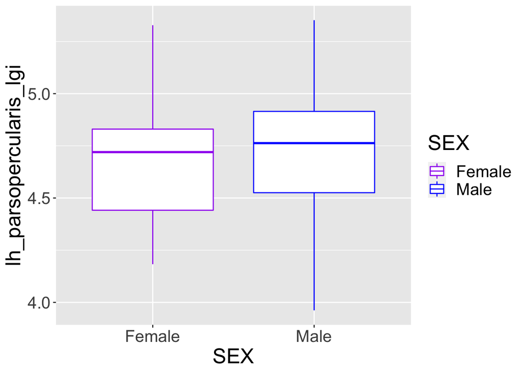

## Sex Results Q>=3

Sex predicts lh pars opercularis LGI, controlling for TBV, dx, and age